# Homework 1 - Data wrangling and visualization

Enter Your Name Here

**Release: 09/30/2020**  
**Due: 10/14/2020**

In this homework, you will write R codes to answer the below questions regarding the flights that departed New York City in 2013. Each question involves some form of data wrangling and data visualization, which we’ve covered until this week. Before you start, please read the below instructions carefully as failure to follow the instructions may result in deductions in your score.

# Before you start

## Instructions

- Download the source Rmd file from the `Code` tab at the upper-right corner of this document.
- In the YAML header, change `author` to your name.
- For each question, write your R code inside the R chunk, starting below the line `# write your code below this comment line`
  - one answer for each question
- You must write your code **inside** the R chunks. Do not change anything else (e.g., chunk options, order of question)
- Do not add additional R chunks

## Submission

- Save your R markdown document as “lastname_firstname_WSUID.Rmd” (e.g., lee_kyunghee_gl3566.Rmd)
- Submit your `Rmd` file on **Canvas**
  - You only need to submit the `Rmd` file, not the output `html` document which is generated from the `Rmd` file.

## Grading

- 15 questions in total, each accounts for 1 point
- **To get the full score for each question, your code must be executable without generating any errors**
- If your code doesn’t run, partial credits will be given.

## R markdown tutorial

- The source RMD file is on `Code` tab on the top.
- You can either `Knit` the entire document to produce a html doc, `Run All` to only run R codes, or run one R chunk at a time by clicking the play button.
- Remember that your code must be inside **R chunks**. Otherwise, your computer would just treat your code as plain text and won’t run it.
- See the instructions and video in [Lab 1](https://khlee42.github.io/datamining/lab/lab-01/lab-01-hello-r.html) for more

# Package and Data

For this assignment, we have two packages to load: `tidyverse` and `nycflights13`. You should be familiar by now with the first package `tidyverse`. The second package is for the `flights` data set we’re using for the assignment: Flights that Departed NYC in 2013 (see https://www.rdocumentation.org/packages/nycflights13/versions/1.0.1 for details). The below code chunk is to load these packages and take a look at the data set.

```r
library(tidyverse)
library(nycflights13)

names(flights)
```

```
##  [1] "year"           "month"          "day"            "dep_time"
##  [5] "sched_dep_time" "dep_delay"      "arr_time"       "sched_arr_time"
##  [9] "arr_delay"      "carrier"        "flight"         "tailnum"
## [13] "origin"         "dest"           "air_time"       "distance"
## [17] "hour"           "minute"         "time_hour"
```

```r
head(flights)
```

```
## # A tibble: 6 x 19
##    year month   day dep_time sched_dep_time dep_delay arr_time sched_arr_time
##   <int> <int> <int>    <int>          <int>     <dbl>    <int>          <int>
## 1  2013     1     1      517            515         2      830            819
## 2  2013     1     1      533            529         4      850            830
## 3  2013     1     1      542            540         2      923            850
## 4  2013     1     1      544            545        -1     1004           1022
## 5  2013     1     1      554            600        -6      812            837
## 6  2013     1     1      554            558        -4      740            728
## # … with 11 more variables: arr_delay <dbl>, carrier <chr>, flight <int>,
## #   tailnum <chr>, origin <chr>, dest <chr>, air_time <dbl>, distance <dbl>,
## #   hour <dbl>, minute <dbl>, time_hour <dttm>
```

# Question 1 - Warm-up

- Q1-1. Remove the columns `year` from your data frame (`flights`) [Hint: `select()`]

```r
flights %>%
  select(-year)
```

```
## # A tibble: 336,776 x 18
##    month   day dep_time sched_dep_time dep_delay arr_time sched_arr_time
##    <int> <int>    <int>          <int>     <dbl>    <int>          <int>
##  1     1     1      517            515         2      830            819
##  2     1     1      533            529         4      850            830
##  3     1     1      542            540         2      923            850
##  4     1     1      544            545        -1     1004           1022
##  5     1     1      554            600        -6      812            837
##  6     1     1      554            558        -4      740            728
##  7     1     1      555            600        -5      913            854
##  8     1     1      557            600        -3      709            723
##  9     1     1      557            600        -3      838            846
## 10     1     1      558            600        -2      753            745
## # … with 336,766 more rows, and 11 more variables: arr_delay <dbl>,
## #   carrier <chr>, flight <int>, tailnum <chr>, origin <chr>, dest <chr>,
## #   air_time <dbl>, distance <dbl>, hour <dbl>, minute <dbl>, time_hour <dttm>
```

- Q1-2. Add a new variable, total_delay, which is the sum of `dep_delay` and `arr_delay`, and sort your data frame in descending order of total_delay. Save the output as a new data frame `flight1`

```r
flights1 <- flights %>%
  mutate(total_delay = dep_delay + arr_delay) %>%
  arrange(desc(total_delay))
```

- Q1-3. Use `flight1` data frame to draw box plots of total delay separately by carriers

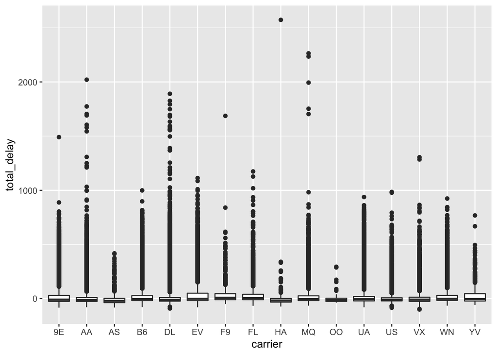

```r
ggplot(flights1, aes(x=carrier, y=total_delay)) +
  geom_boxplot()
```

- Q1-4. Use `flights1` data frame and visualize the relationship between total delay time and flight distance. [Hint: `ggplot` and `geom_point`]

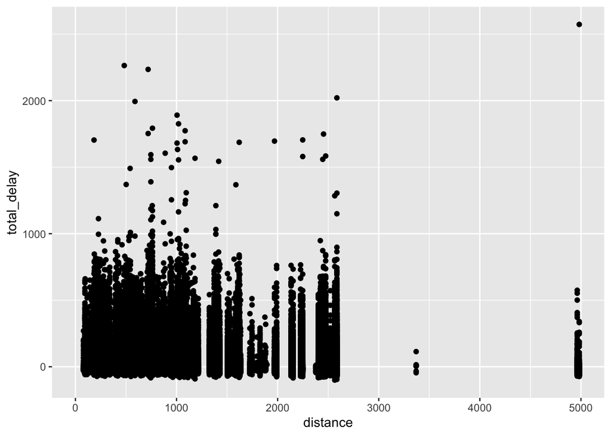

```r
ggplot(flights1, aes(x=distance, y=total_delay)) +
  geom_point()
```

# Question 2 - Which airline carrier is the most frequently delayed?

- Q2-1. Filter `flights` whose `dep_delay` or `arr_delay` is greater than 60, and save it as a new data `major_delay`

```r
major_delay <- flights %>%
  filter(dep_delay > 60 | arr_delay > 60)
```

- Q2-2. Use `major_delay` data frame to create a frequency table of delayed flights by carrier, and save it as a new data frame `carrier_table` [Hint: `count()`]

```r
carrier_table <- major_delay %>%
  count(carrier)
```

- Q2-3. Use `carrier_table` to draw a pie chart to examine the most frequently delayed carrier [Hint: set `x`="" and `y`=n]

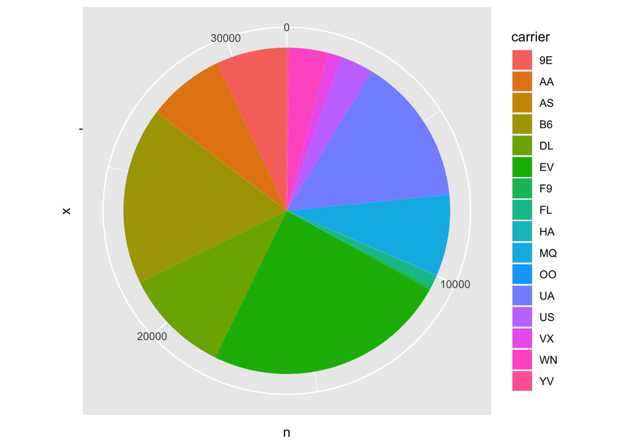

```r
ggplot(carrier_table, aes(x="", y=n, fill = carrier)) +
  geom_col() +
  coord_polar("y", start=0)
```

# Question 3 - JFK-departed flights

- Q3-1. Filter `flights` that departed from JFK airport and save it as `JFK_flights`

```r
JFK_flights <- flights %>%
  filter(origin=="JFK")
```

- Q3-2. Use `JFK_flights` to create the histogram of departure delay (`dep_delay`) of flights that departed from JFK.

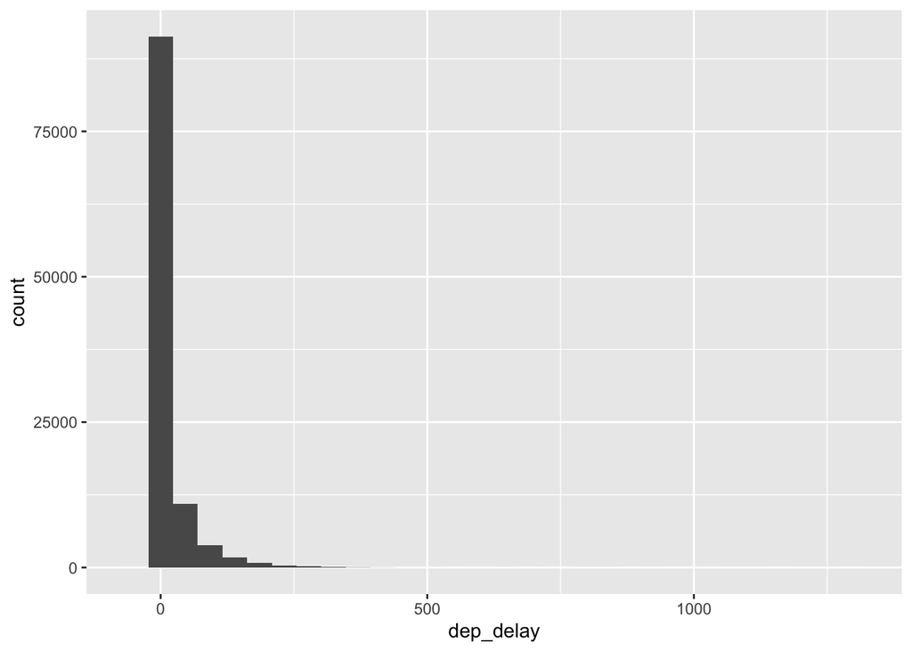

```r
ggplot(JFK_flights, aes(x=dep_delay)) +
  geom_histogram()
```

- Q3-3. Use `JFK_flights` to create a frequency table of flight counts by destination.

```r
dest_table<-JFK_flights %>%
  count(dest) %>%
  arrange(desc(n))
```

- Q3-4. Use `dest_table` to visualize the number of flights by destination, in decreasing order, that departed from JFK [Hint: try both `geom_col()` and `geom_bar()` see if which one would suit better. `reorder()`]

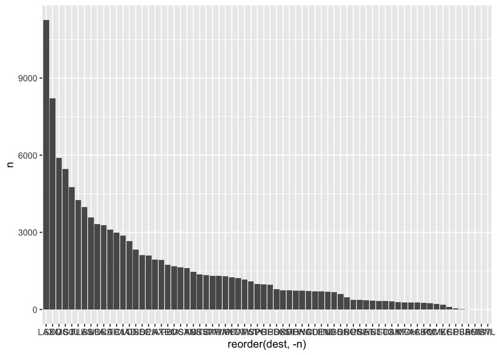

```r
ggplot(dest_table, aes(x=reorder(dest, -n), y=n)) +
  geom_col()
```

# Question 4 - Which airline carrier is the most frequently departed from each of the NYC airports?

- Q4-1. Group `flights` by (“origin”, “carrier”) and count the number of flights for each group [Hint: use `group_by()` and `summarize()`]

```r
flights %>%
  group_by(origin, carrier) %>%
  summarize(n=n())
```

```
## # A tibble: 35 x 3
## # Groups:   origin [3]
##    origin carrier     n
##    <chr>  <chr>   <int>
##  1 EWR    9E       1268
##  2 EWR    AA       3487
##  3 EWR    AS        714
##  4 EWR    B6       6557
##  5 EWR    DL       4342
##  6 EWR    EV      43939
##  7 EWR    MQ       2276
##  8 EWR    OO          6
##  9 EWR    UA      46087
## 10 EWR    US       4405
## # … with 25 more rows
```

- Q4-2. Use `flights` to create a frequency table of the number of flights by (“origin”, “carrier”), and save it as a new data frame `count_flights`[Hint: use `count()` this time. Q5-1 and Q5-2 have the same output!]

```r
count_flights <- flights %>%
  count(origin, carrier)
```

- Q4-3. Use `count_flights` to draw the point plots of the number of flights by carrier (i.e., x-axis: `carrier` and y-axis: `n`) and change colors by carrier [Hint: `geom_point()`]

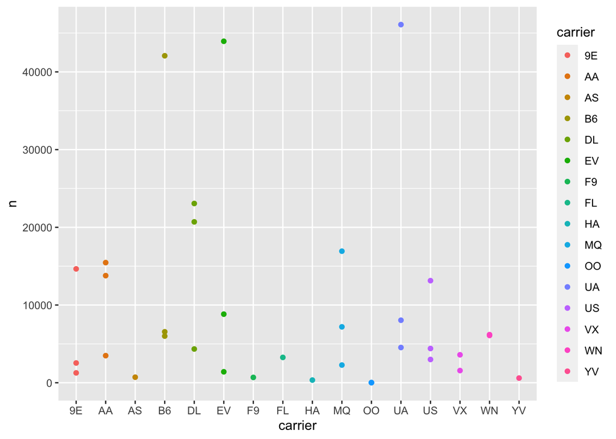

```r
ggplot(count_flights, aes(x=carrier, y=n, color=carrier)) +
  geom_point()
```

- Q4-4. Separate the above plot by “origin”, and label x-axis as “Carrier for each origin airport” and y-axis as “Frequency” [Hint: use `facet_wrap()` or `facet_grid()`]

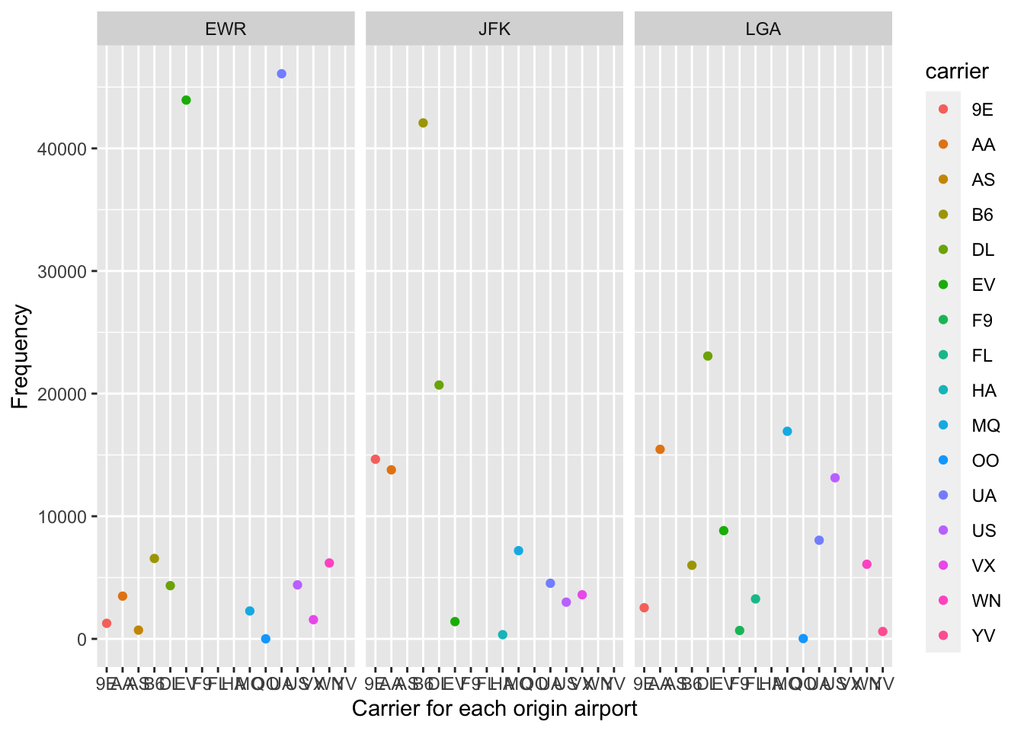

```r
ggplot(count_flights, aes(x=carrier, y=n, color=carrier)) +
  geom_point() +
  labs(x="Carrier for each origin airport", y="Frequency") +
  facet_wrap(.~origin)
```